# Replication 4: “What the Demolition of Public Housing Teaches Us about the Impact of Racial Threat on Political Behavior”

Keeley MacAfee

4/1/2019

# Abstract

In “What the Demolition of Public Housing Teaches Us about the Impact of Racial Threat on Political Behavior,” Ryan Enos examines the destruction of housing projects in Chicago and the effects it had on citizens’ political behavior/preferences. Enos finds that white people living close to a project tended to vote less once the project was demolished.

# Data Creation

```
## [1] 430564
```

# Figure 1 Treatment Effects

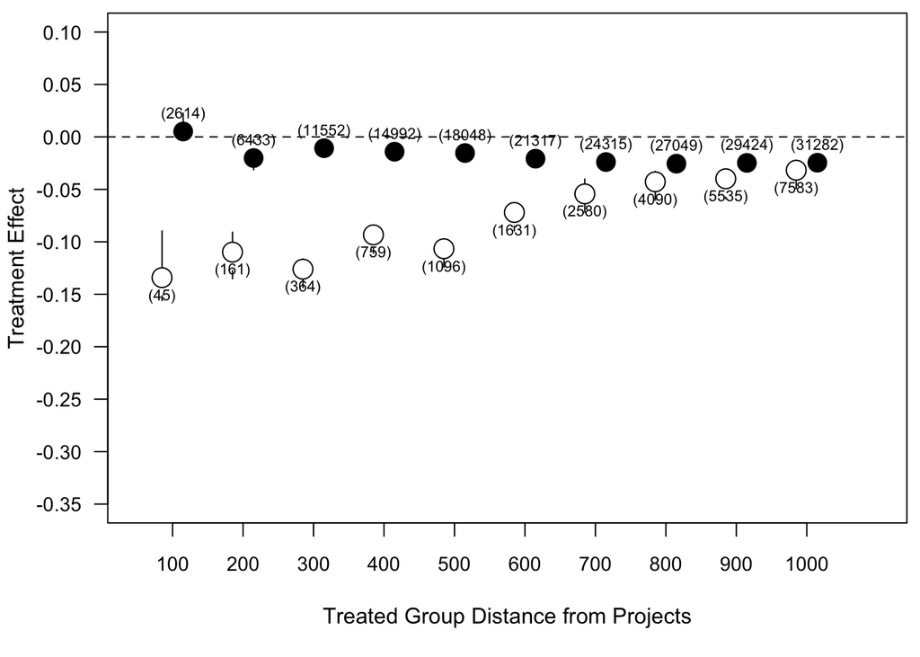

*Note*: Difference-in-differences results for treatment groups defined by increasing distance from the demolished projects. Differences are for the mean turnout in 2004 minus the mean turnout in 2000 for the treatment group minus the same difference for the control group. White circles represent the mean effect on white voters; black circles represent the mean effect on black voters. The N in each treatment group is in parentheses next to the mean effect. Vertical lines represent the 95% confidence intervals generated by bootstrapped standard errors of the difference between treatment and control.

# Figure 2 Treatment Effects Using Matched White Voters Near Nondemolished Projects for Control Group

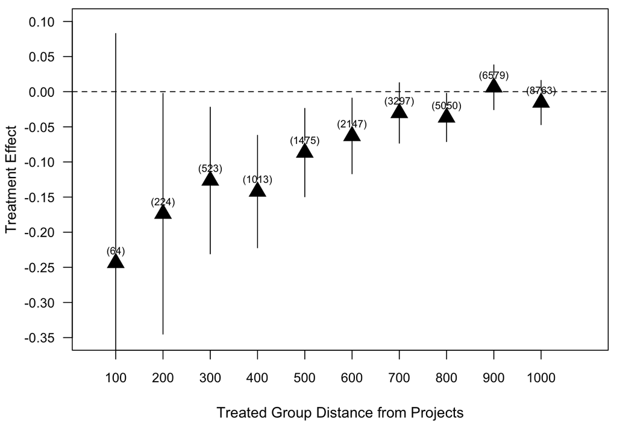

*Note*: Coefficients on treatment as defined by increasing distance from the demolished projects from OLS regressions on change in turnout from 2000 to 2004 (triangles). N for the regression using matched groups is next to the point representing the coefficient. The treatment group is matched to a control group of white voters living near projects that were not demolished, using nearest neighbor matching. Regressions include variables used in matching as controls. Vertical lines represent the 95% confidence intervals generated by bootstrapped standard errors on the treatment coefficient.

# Figure 3 Treatment Effects Using Matched Black Control Groupand Controlling for Homeownership

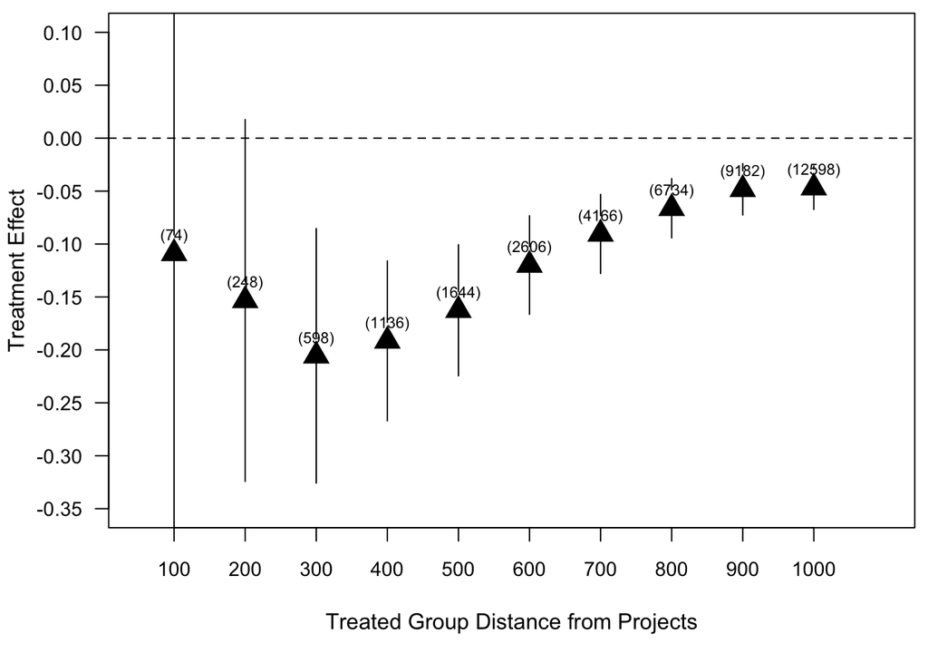

*Note*: Coefficients on treatment as defined by increasing distance from the demolished projects from OLS regressions on change in turnout from 2004 to 2000 (triangles). N for the regression using matched groups is next to the point representing the coefficient. The white treatment group is matched to a black control group of the same N using nearest neighbor matching and including variables on homeownership and home value. Regressions include variables used in matching as controls. Vertical lines represent the 95% confidence intervals generated by bootstrapped standard errors on the treatment coefficient.

# Figure 4 Effects of Distance and Size of Projects

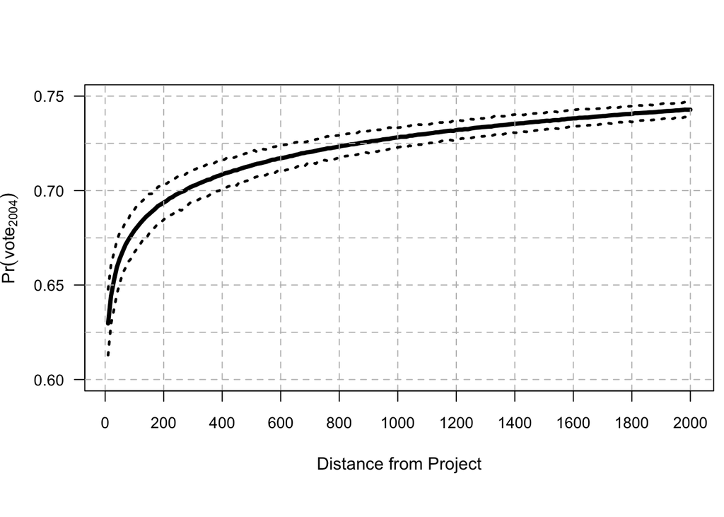

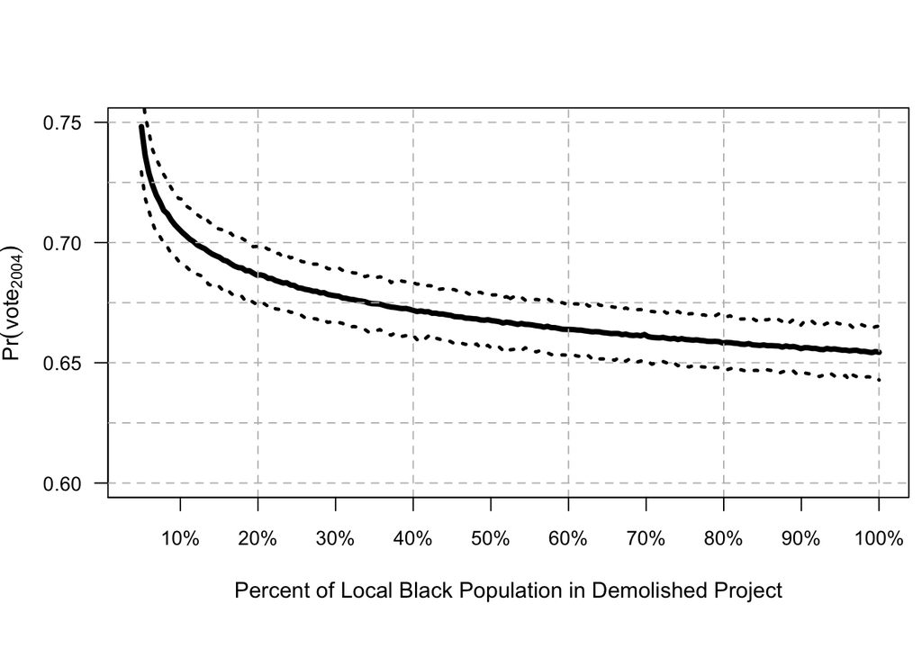

*Note*: Predicted effects generated from vote2004 = 0 + 1(log(distance)) + 2(log(localpercent)) + vote2000, with white voters. Figure 4(a) is the predicted probability that a person who voted in 2000 will vote in 2004 with increasing distance, while holding size at its mean. Figure 4(b) is the predicted probability that a person who voted in 2000 will vote in 2004, with increasing outgroup population size, with distance = 100. Dotted lines represent 95% confidence intervals generated by bootstrapped standard errors.

# Figure 5

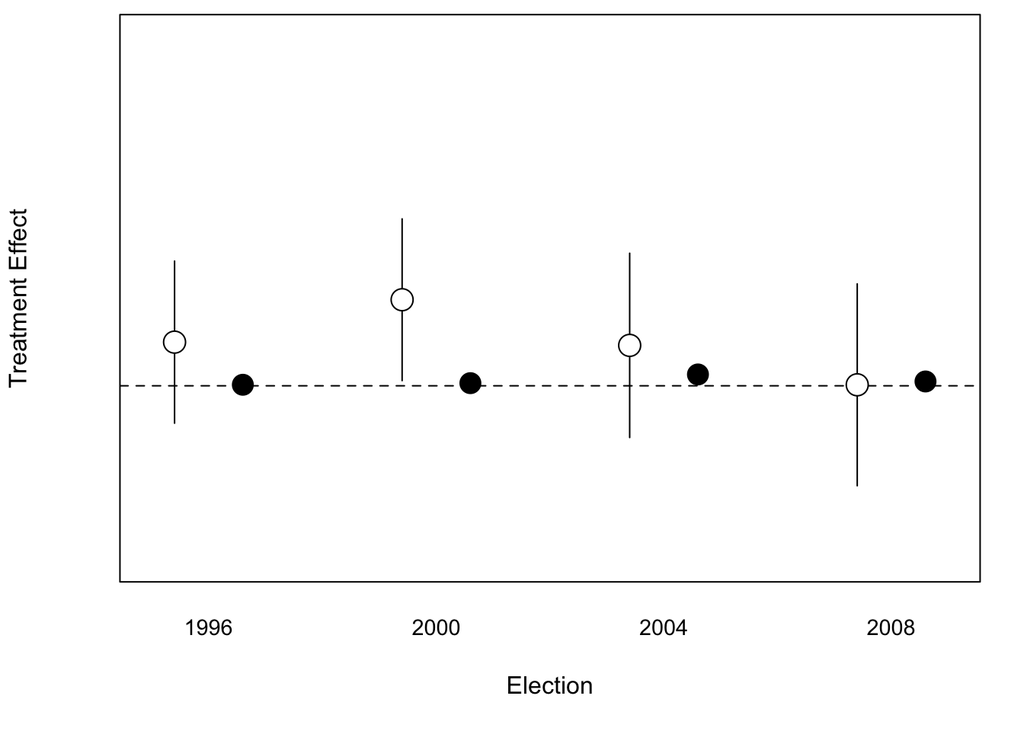

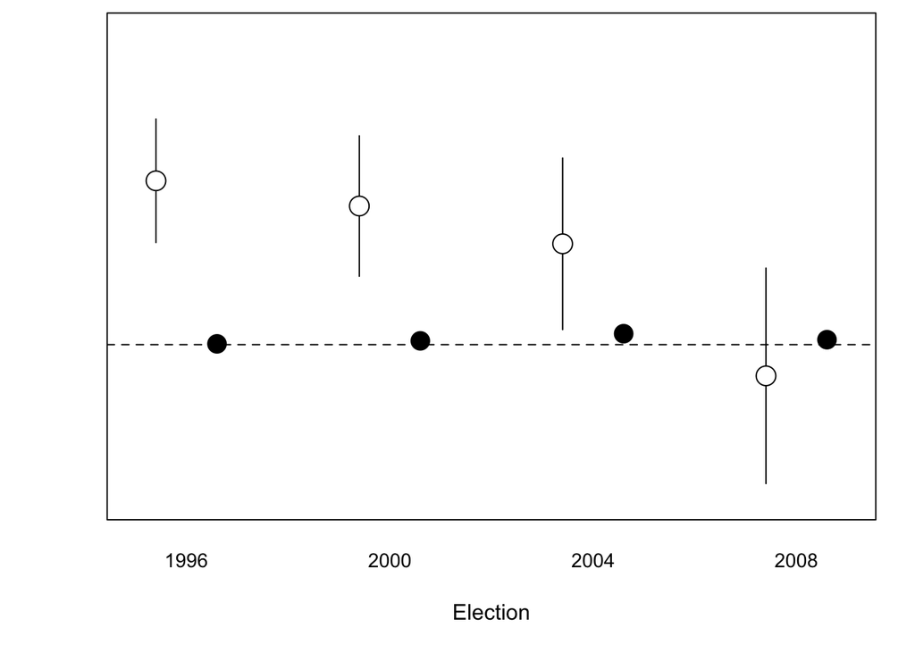

*Note*: Figure 5(a) shows differences in weighted mean Republican vote for precincts with d ≤ 1,000 and matched precincts with d > 1,000 for white voters (white circles) and black voters (black circles). Figure 5(b) shows differences in weighted mean Republican vote for white voters and black voters matched with precincts with d ≤ 1,000 from nondemolished projects.

# Figure 6

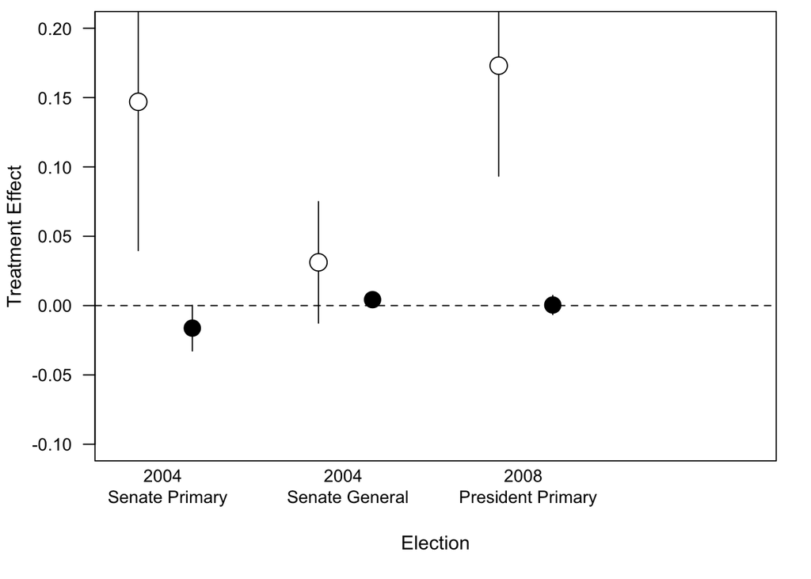

*Note*: Differences in weighted mean Obama vote for precincts with d ≤ 1,000 for de- molished projects and matched precincts with d ≤ 1,000 for nondemolished projects for white voters (white circles) and black voters (black circles).

# References

Enos, Ryan D. 2016. “What the Demolition of Public Housing Teaches Us about the Impact of Racial Threat on Political Behavior.” American Journal of Political Science 60 (1): 123-142